# Rcpp Modules, suite et mise à jour de la version FinistR2018

Cette présentation de Rcpp Modules est une mise à jour et correctif de la [version FinistR2018](https://stateofther.github.io/finistR2018/atelier2_rcpp_modules.html)

Marie-Pierre Etienne https://marieetienne.github.io/ (Agrocampus Ouest)http://agrocampus-ouest.fr , Pierre Gloaguen https://papayoun.github.io/ (AgroParisTech)http://agroparistech.fr , Gabriel Lang (AgroParisTech)http://agroparistech.fr  
2019-08-29

# Introduction

Pour des raisons de performance, on est fréquemment amené à écrire une partie de son code dans un langage compilé, notamment C++. Pour faire communiquer R et C++, il faut écrire une interface pour passer les objets R à C++ et à l’inverse passer les résultats de C++ à R. Le package Rcpp a été développé pour faciliter l’interfaçage entre les deux langages.

Par ailleurs, la programmation objet permet une structuration forte du code et assure un développement modulaire. Il est intéressant de partager au moins partiellement la structure d’objets entre les deux langages. RcppModules permet d’exposer des classes C++ et les rendre visibles et accessibles depuis R.

L’installation de Rcpp et son utilisation sont décrites dans le [document de 2018](https://stateofther.github.io/finistR2018/atelier2_rcpp_modules.html). On se concentre ici sur la partie RcppModules intégrée au sein d’un package.

## Création d’un package contenant des sources C++ au sein d’un package

Le fichier `DESCRIPTION` a été modifié pour indiquer la dépendance à Rcpp.

Et comme indiqué dans les sorties R de la commande `use_rcpp()`, il est **indispensable** de créer un fichier `myPackage-package.R` (le nom importe peu, mais on adoptera la convention `nomPackage-package.R`) dans le sous répertoire `R` du package.

Pour illustrer le fonctionnement du package, on veut créer une classe Random_walk. Commençons par une fontion qui simule la position à linstant t, partant de x0.

## Création d’une fonction C++

On peut ensuite compiler ce package, en cliquant INSTALL and Restart ou avec le raccourci CTL + SHIFT + b.

A l’issue de la compilation plusieurs fichiers sont créés, notamment `src\RcppExports.cpp` et `R\RcppExports.R` qui permettent de faire le lien entre R et C++.

Il faut mettre à jour les fichiers de config (NAMESPACE, RcppExports.R, RcppExports.cpp) avec la commande `devtools:document()`, puis copiler et reinstaller le package avec CTL + SHIFT + b .

La fonction compute_next_pos existe maintenant dans R, elle appelle la fonction du même nom codée en C et passe les arguments.

La marche aléatoire dépend d’un parametre, on veut créer une classe avec un membre (la variance) et des méthodes pour simuler et accéder au membre.

## Création d’une classe en C++

Enfin, on génère à nouveau le NAMESPACE avec `devtools::document()` et on recompile, réinstalle.

La classe n’est pas exportée et n’est pas visible depuis R. Il faut écrire des fonctions supplémentaires pour interfacer. La logique à ce stade est d’écrire une fonction c++ qui va faire le travail et notamment créer une instance de la classe Random_walk et d’exporter cette fonction en R pour la rendre accessible à l’utilisateur. Dans ce cas la classe C++ n’a de pas du tout de vocation à être modifié par un code R.

Si on souhaite pouvoir depuis R choisir et/ou modifier la variance de notre objet marche aléatoire il faut exposer la classe dans R. C’est l’objectif de RcppModule.

## RcppModules

On va ensuite écrire une fonction R qui a pour rôle de créer l’objet de classe Random_walk dans R et de le rendre accessible dans R. On crée ainsi le fichier `create_class.R` dans le répertoire R

Il faut ensuite générer à nouveau le NAMESPACE avec devtools::document() et enuiste compiler le package avec CTL + SHIFT + b.

Enfin on peut maintenant créer un objet de type Random_walk dans R

```
C++ object <0x4c23c20> of class 'Random_walk' <0x39db190>
```

C’est une réferérence sur un objet C++.

On a exposé les accesseurs et on peut donc demander la valeur de l’écart type

```
[1] 3
```

On peut aussi modifier cette valeur

```
[1] 2
```

Enfin on peut utiliser les méthodes de la classe qui ont été exposées

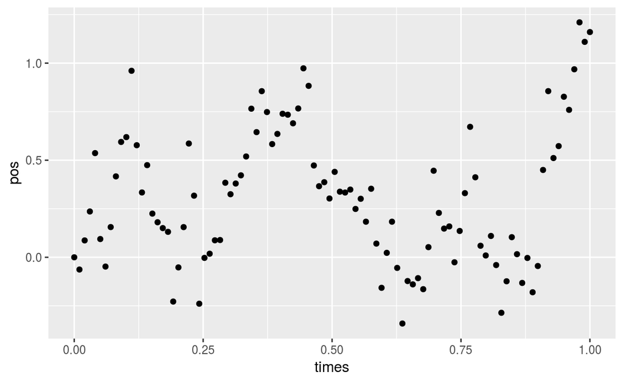

En cas de problème, et si des erreurs se produisent et avant de perdre son calme, il faut nettoyer manuellement le répertoire de développement du package. C’est à dire, il faut supprimer les fichiers

- `NAMESPACE`
- `R/RcppExports.R`
- `src/RcppExports.cpp`
- `src/*.so`
- `src/*.o`

Pour plus de détails sur la syntaxe de RcppModules, on peut consulter (“RcppModules Vignette,” n.d.).

“RcppModules Vignette.” n.d. https://CRAN.R-project.org/package=Rcpp/vignettes/Rcpp-modules.pdf. https://doi.org/10.7287/peerj.preprints.3188v1.